# K-Means

# Tarea 4.

# Jorge Porras Araya

Librerias

```r
#library('ggplot2')
library(tidyverse)
library(GGally)
library(reshape2)   # for melt function
```

1. Desarolle el Análisis del Problema

Desarrollar el analisis por medio de kMeans del dataset Wholesale, que se refiere a las ventas de un distribuidos medidas en unidades monetarias (mu) para diversas categorias de productos.

El dataset cuenta con las siguientes columnas

1. FRESH: annual spending (m.u.) on fresh products (Continuous);
2. MILK: annual spending (m.u.) on milk products (Continuous);
3. GROCERY: annual spending (m.u.)on grocery products (Continuous);
4. FROZEN: annual spending (m.u.)on frozen products (Continuous)
5. DETERGENTS_PAPER: annual spending (m.u.) on detergents and paper products (Continuous)
6. DELICATESSEN: annual spending (m.u.)on and delicatessen products (Continuous);
7. CHANNEL: customers’ Channel - Horeca (Hotel/Restaurant/Café) or Retail channel (Nominal)
8. REGION: customers’ Region – Lisbon, Oporto or Other (Nominal)

Fuente del dataset: https://archive.ics.uci.edu/ml/datasets/Wholesale+customers

2. Cargue el archivo Wholesale customers data.csv en una variable

```r
Wholesale <- data.frame(read.csv("Wholesale.csv"))
```

Se pasan las variables nominales a factor con sus respectivas etiquetas segun la documentacion de la pagina web.

```r
Wholesale$Channel <- factor(Wholesale$Channel,
                          levels = c(1, 2),
                          labels = c("HoReCa", "Retail"))
Wholesale$Region <- factor(Wholesale$Region,
                          levels = c(1, 2, 3),
                          labels = c("Lisbon", "Oporto", "Other"))
```

Observamdo la variable Fresh, tenemos algunos valores muy elevados que probablemente no representan a la mayoria de las compras, por lo cual se decide remover los valores mayores a 60000

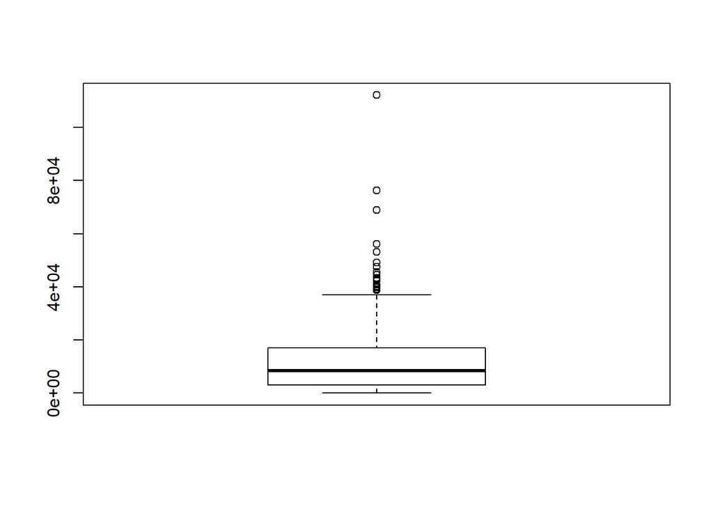

```r
boxplot(Wholesale$Fresh)
```

de igual manera con la variable Milk, se liminan los valores mayores a 50000

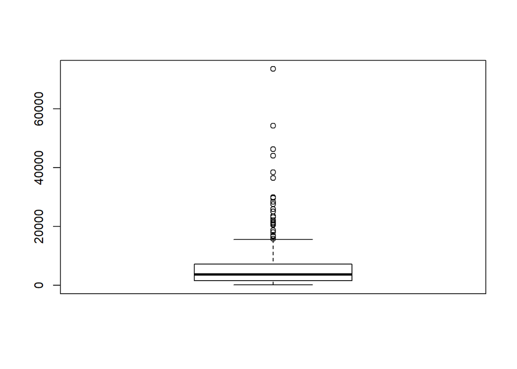

```r
boxplot(Wholesale$Milk)
```

de Grocery los mayores a 50000

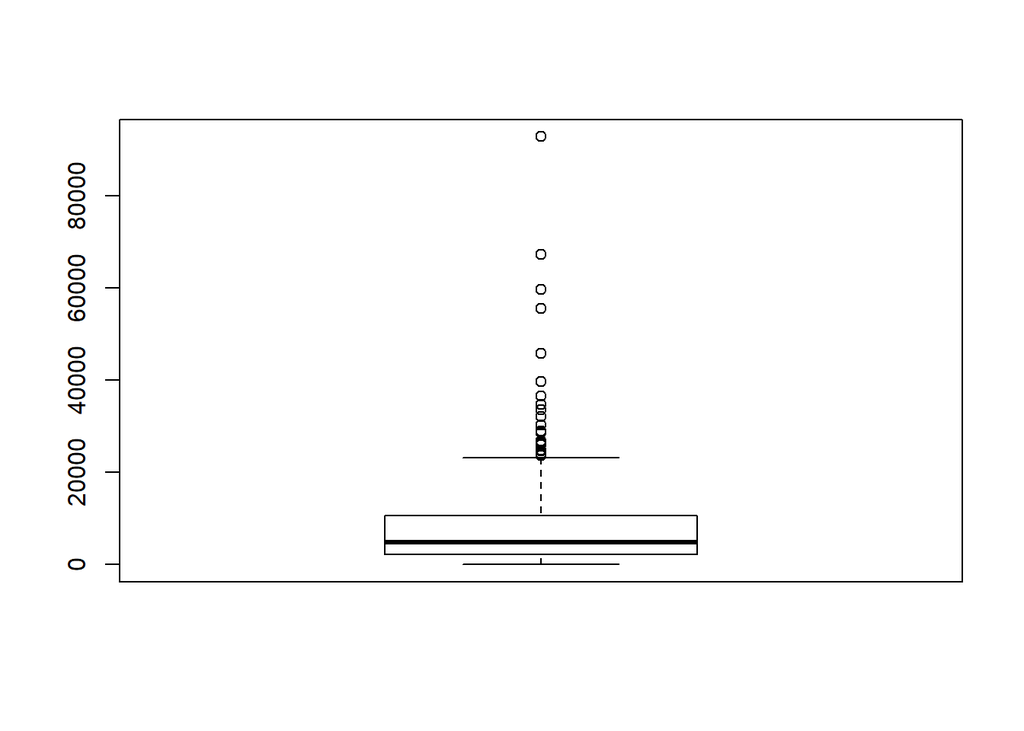

```r
boxplot(Wholesale$Grocery)
```

De Frozen los mayores a 30000

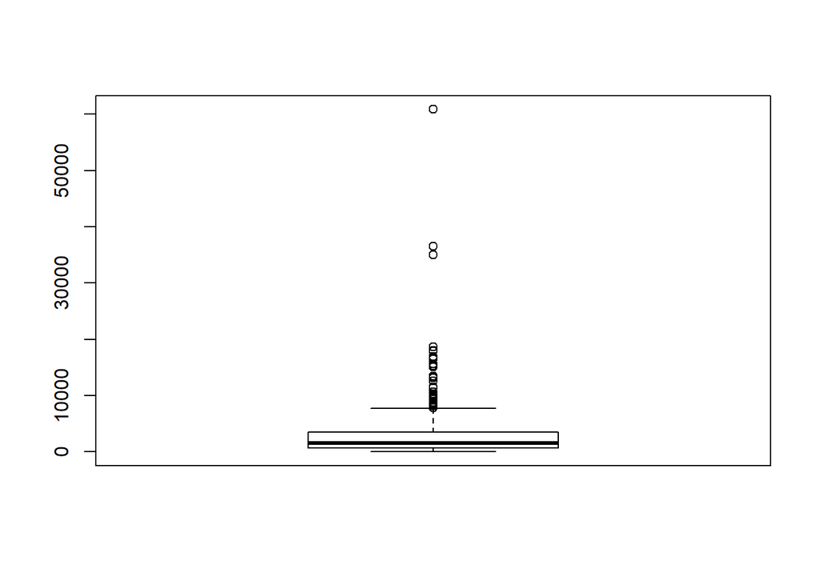

```r
boxplot(Wholesale$Frozen)
```

De detergents los mayores a 30000

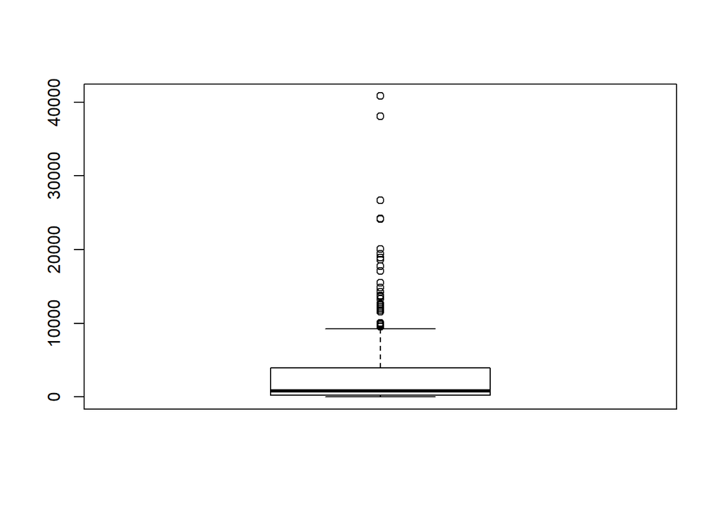

```r
boxplot(Wholesale$Detergents_Paper)
```

de delicatessen los mayores a 10000

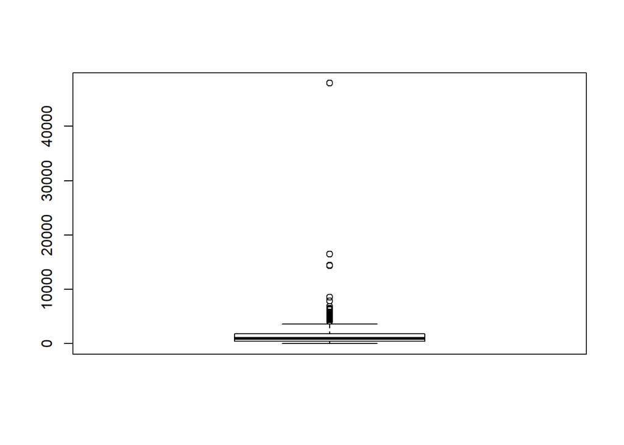

```r
boxplot(Wholesale$Delicassen)
```

```r
elements_before <- length(Wholesale$Channel)

Wholesale <- Wholesale %>%
  filter (Fresh < 60000,
          Milk < 50000,
          Grocery < 50000,
          Frozen < 30000,
          Detergents_Paper < 30000,
          Delicassen < 10000)

elements_after <- length(Wholesale$Channel)
elements_deleted <- elements_before - elements_after
percent_deleted = 100 * elements_deleted / elements_before
```

Se puede observar que se eliminaron 14 filas

```r
elements_deleted
```

```
## [1] 14
```

Que representan el 3.18% de los datos originales

```r
percent_deleted
```

```
## [1] 3.181818
```

3. Desarolle el Entendimiento de los Datos

Se tienen 426 observaciones de 8 variables (2 factor y 6 numericas)

```r
glimpse(Wholesale)
```

```
## Observations: 426
## Variables: 8
## $ Channel          <fct> Retail, Retail, Retail, HoReCa, Retail, Retai...
## $ Region           <fct> Other, Other, Other, Other, Other, Other, Oth...
## $ Fresh            <int> 12669, 7057, 6353, 13265, 22615, 9413, 12126,...
## $ Milk             <int> 9656, 9810, 8808, 1196, 5410, 8259, 3199, 495...
## $ Grocery          <int> 7561, 9568, 7684, 4221, 7198, 5126, 6975, 942...
## $ Frozen           <int> 214, 1762, 2405, 6404, 3915, 666, 480, 1669, ...
## $ Detergents_Paper <int> 2674, 3293, 3516, 507, 1777, 1795, 3140, 3321...
## $ Delicassen       <int> 1338, 1776, 7844, 1788, 5185, 1451, 545, 2566...
```

Revisando los NAs (en la pagina decia que no habian), se corrobora la no existencia de NA.

```r
sum(is.na.data.frame(Wholesale))
```

```
## [1] 0
```

Informacion acerca de la distribucion de los datos en la tabla

```r
summary(Wholesale)
```

```
##    Channel       Region        Fresh            Milk          Grocery
##  HoReCa:290   Lisbon: 77   Min.   :    3   Min.   :   55   Min.   :    3
##  Retail:136   Oporto: 45   1st Qu.: 3072   1st Qu.: 1497   1st Qu.: 2132
##               Other :304   Median : 8065   Median : 3596   Median : 4603
##                            Mean   :11094   Mean   : 5139   Mean   : 7198
##                            3rd Qu.:16094   3rd Qu.: 7063   3rd Qu.: 9928
##                            Max.   :56159   Max.   :29892   Max.   :45828
##      Frozen      Detergents_Paper    Delicassen
##  Min.   :   25   Min.   :    3.0   Min.   :   3.0
##  1st Qu.:  696   1st Qu.:  256.0   1st Qu.: 404.2
##  Median : 1474   Median :  799.5   Median : 927.0
##  Mean   : 2693   Mean   : 2581.8   Mean   :1276.8
##  3rd Qu.: 3370   3rd Qu.: 3841.5   3rd Qu.:1752.2
##  Max.   :18711   Max.   :24231.0   Max.   :7844.0
```

4. Utilizando barplot cree un gráfico de los atributos del dataset, observe las correlaciones entre atributos

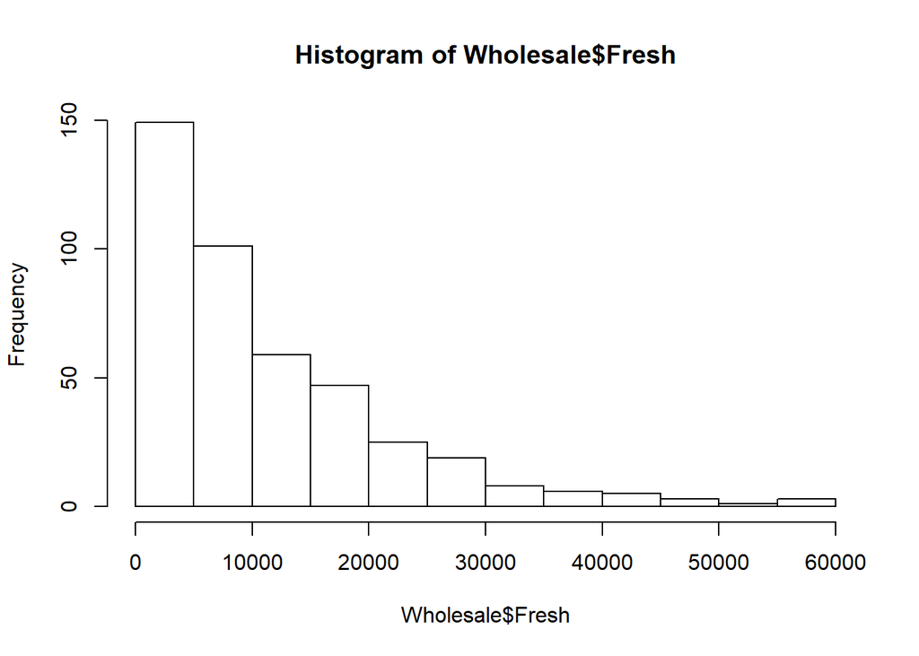

```r
hist(Wholesale$Fresh)
```

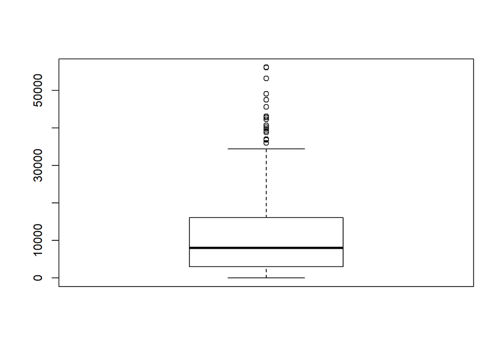

```r
boxplot(Wholesale$Fresh)
```

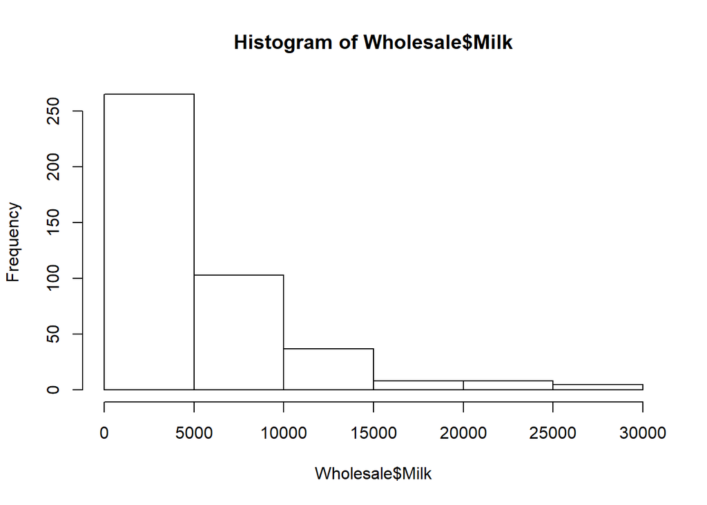

```r
hist(Wholesale$Milk)
```

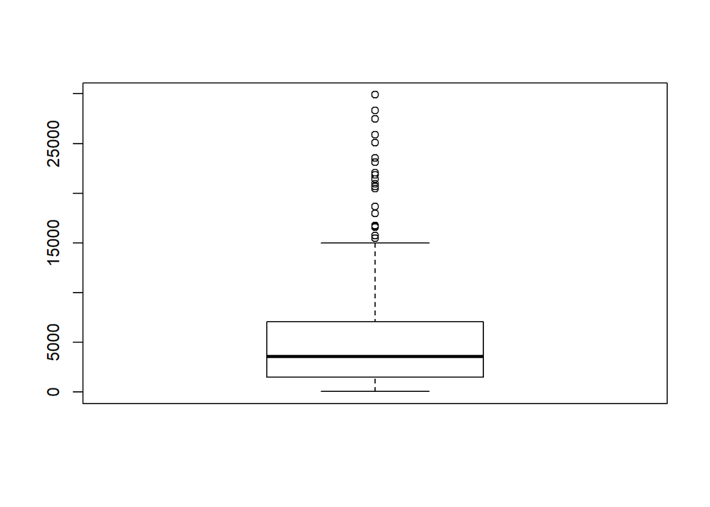

```r
boxplot(Wholesale$Milk)
```

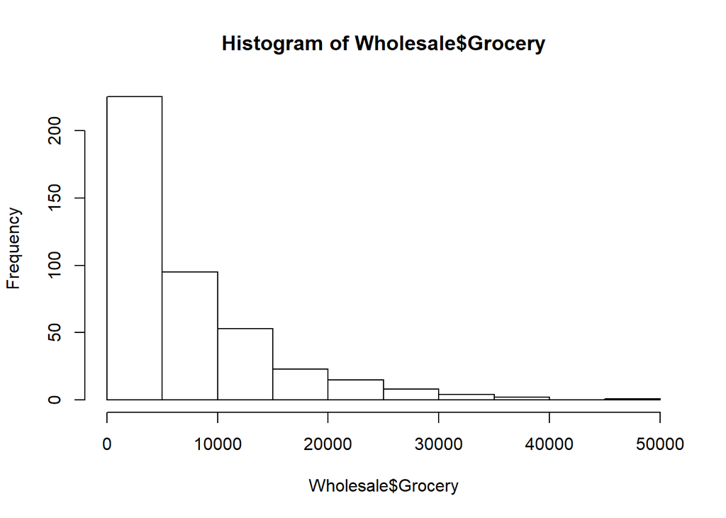

```r
hist(Wholesale$Grocery)
```

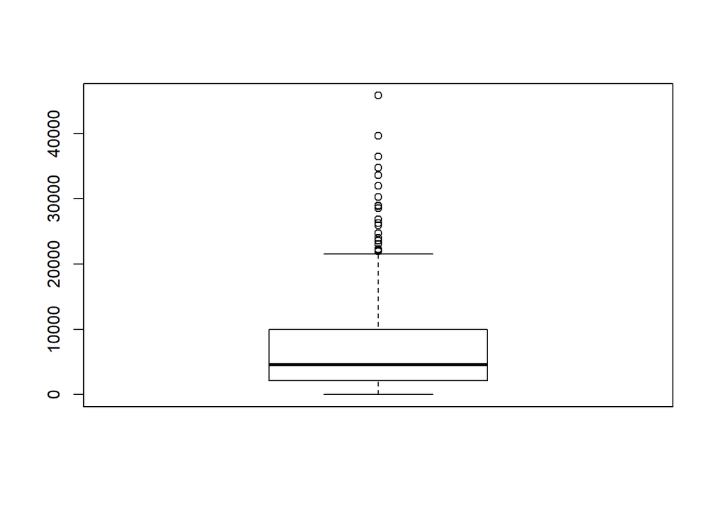

```r
boxplot(Wholesale$Grocery)
```

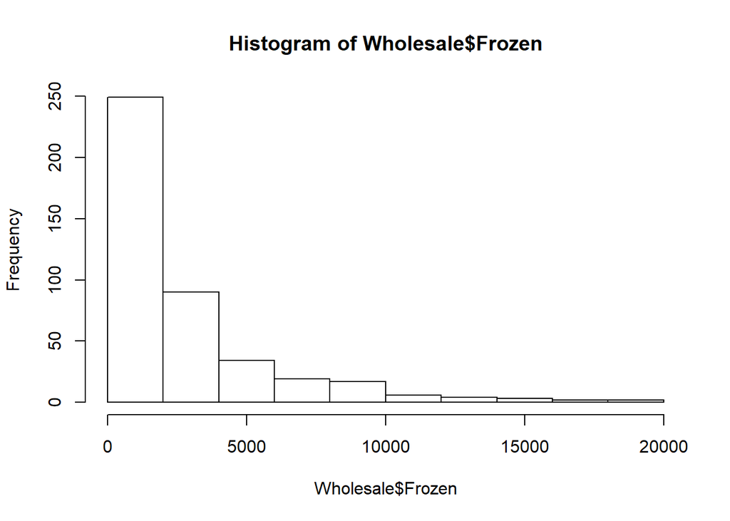

```r
hist(Wholesale$Frozen)
```

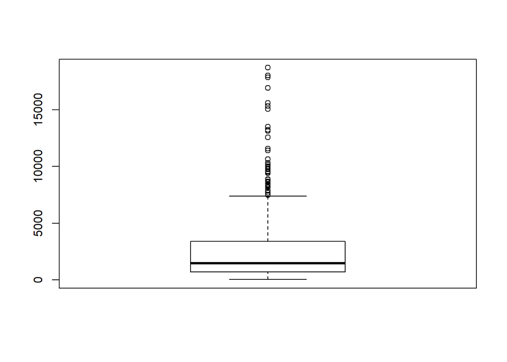

```r
boxplot(Wholesale$Frozen)
```

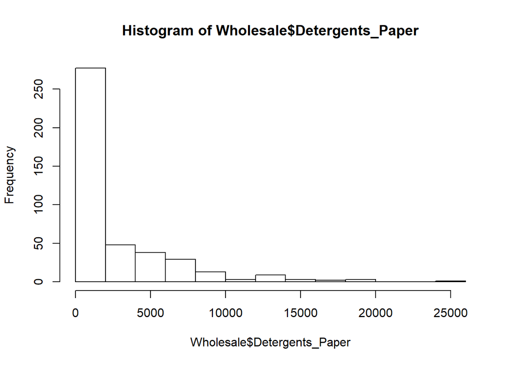

```r
hist(Wholesale$Detergents_Paper)
```

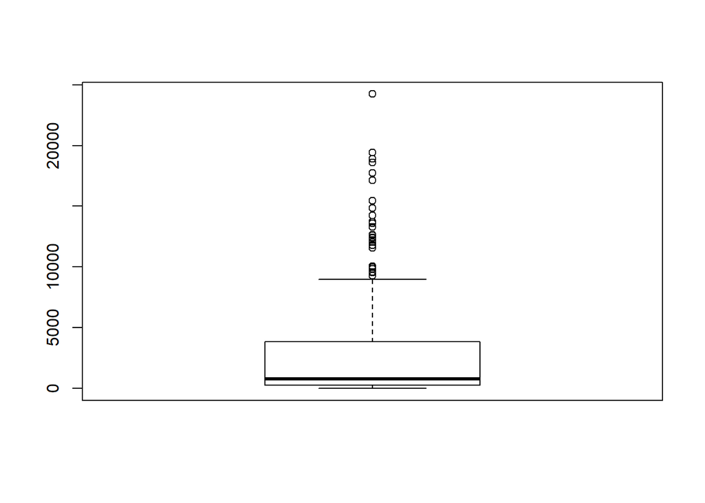

```r
boxplot(Wholesale$Detergents_Paper)
```

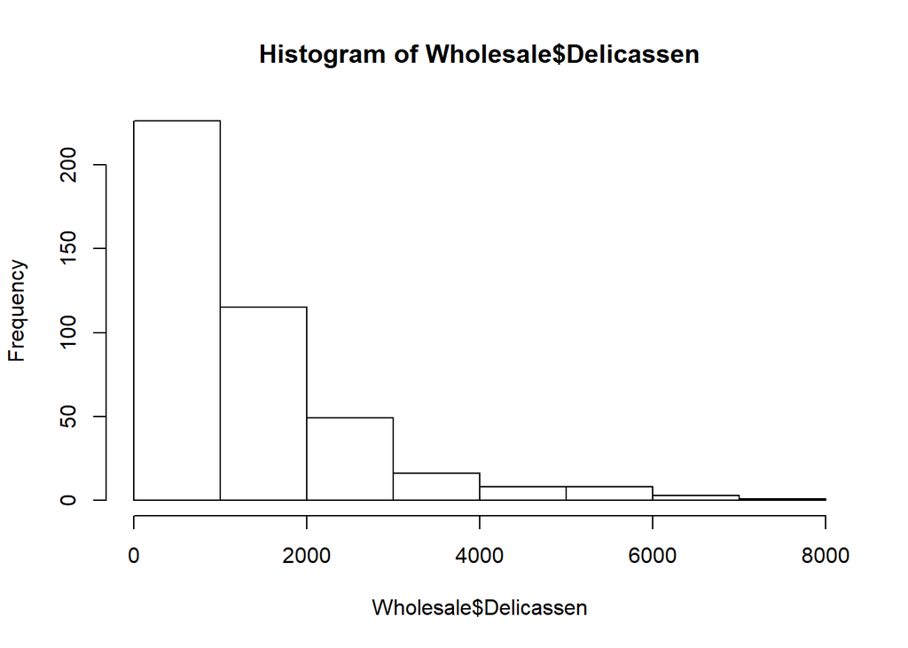

```r
hist(Wholesale$Delicassen)
```

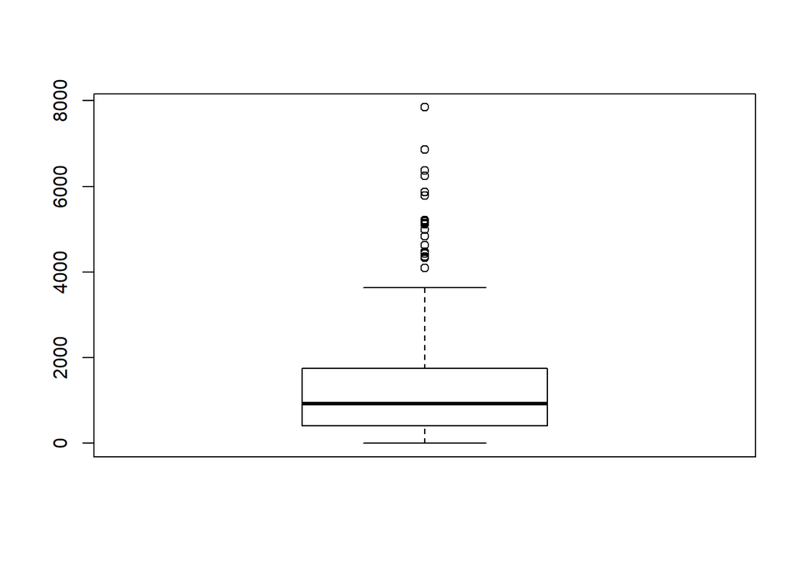

```r
boxplot(Wholesale$Delicassen)
```

Del siguiente plot podemos observar que las corelaciones mas altas las tenemos entre: Groceries - Milk Groceries - Detergent_Paper Milk - Detergent_Paper

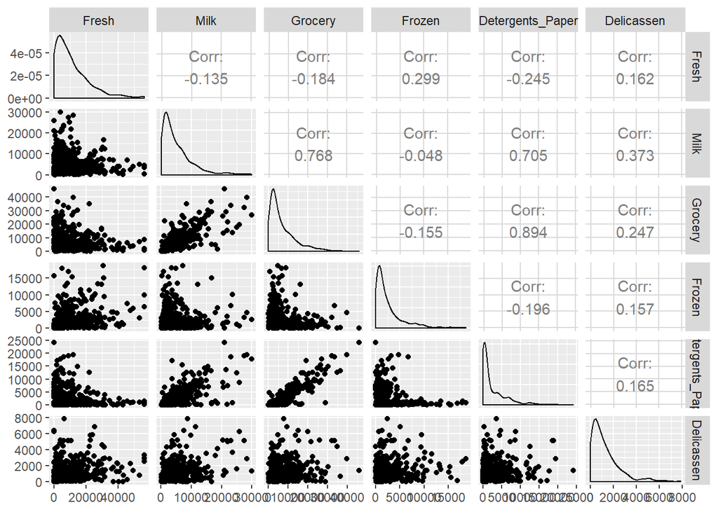

```r
ggpairs(Wholesale[-c(1, 2)], progress = F)
```

Se puede notar que la mayor parte de las ventas se encuentran en el Channel HoReCa y en la region Others

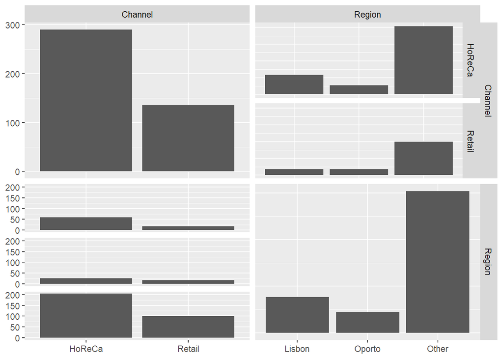

```r
ggpairs(Wholesale[c(1, 2)], progress = F)
```

5. Explique el siguiente gráfico

La funcion melt() deja las variables tipo factor y de las demas crea una sola columna “variable” tipo factor con el nombre y una columna “value” con el valor

```r
melted_data <- melt(Wholesale)
glimpse(melted_data)
```

```
## Observations: 2,556
## Variables: 4
## $ Channel  <fct> Retail, Retail, Retail, HoReCa, Retail, Retail, Retai...
## $ Region   <fct> Other, Other, Other, Other, Other, Other, Other, Othe...
## $ variable <fct> Fresh, Fresh, Fresh, Fresh, Fresh, Fresh, Fresh, Fres...
## $ value    <int> 12669, 7057, 6353, 13265, 22615, 9413, 12126, 7579, 5...
```

El siguiente grafico muestra las ventas de los productos para cada canal, son los boxplot que muestran las distribucion de ventas de cada producto para los Caneles HoReCa y Retail.

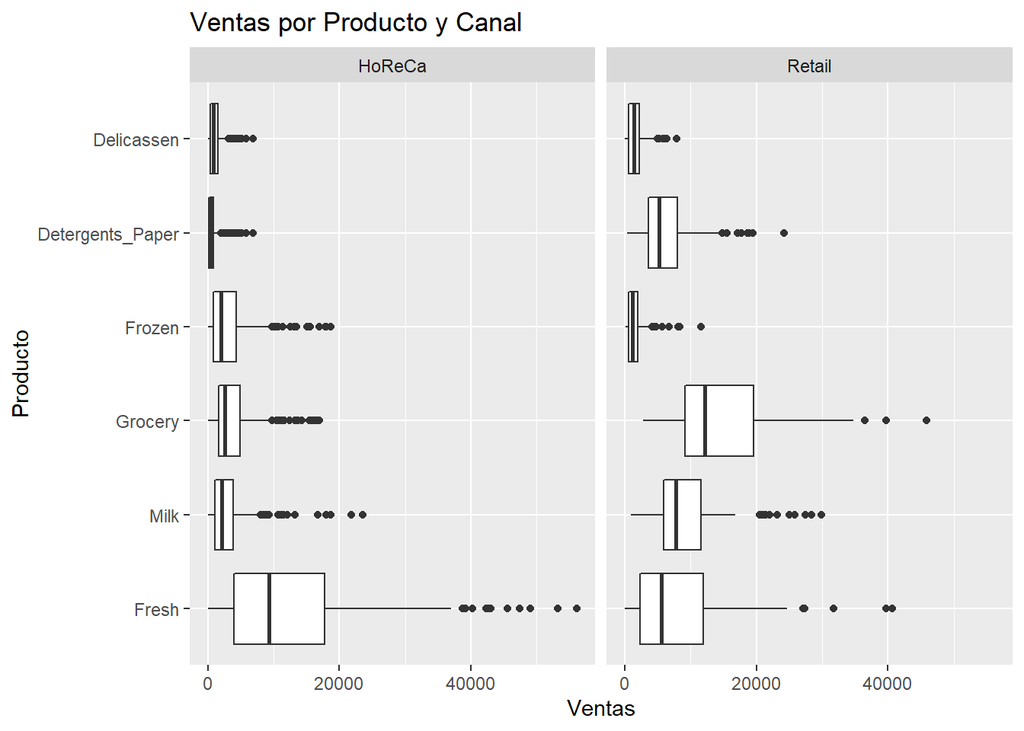

```r
#Grafico
bxplt <- ggplot(data = melted_data, aes(x= variable, y = value))
bxplt <- bxplt + geom_boxplot()
bxplt <- bxplt + facet_wrap(~Channel)
bxplt <- bxplt + coord_flip()
bxplt <- bxplt + labs(x = 'Producto', y  = 'Ventas')
bxplt <- bxplt + ggtitle('Ventas por Producto y Canal')
bxplt
```

De manera semejante, el siguiente grafico muestra la distribucion de ventas de productos para cada Region (Lisbon, Oporto y Otras)

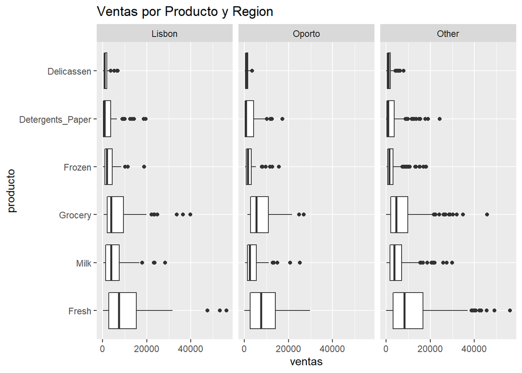

```r
#Grafico
bxplt2 <- ggplot(data = melted_data, aes(x= variable, y = value))
bxplt2 <- bxplt2 + geom_boxplot()
bxplt2 <- bxplt2 + facet_wrap(~Region)
bxplt2 <- bxplt2 + coord_flip()
bxplt2 <- bxplt2 + labs(x = 'producto', y  = 'ventas')
bxplt2 <- bxplt2 + ggtitle('Ventas por Producto y Region')
bxplt2
```

6. Cree un modelo de agrupación K- Means Para agrupar a los clientes con base al consumo, vamos a utilizar solo las variables Fresh, Milk, Grocery, Frozen, Detergents_Paper y Delicassen. En este caso, vamos a intentar agrupar los clientes en 5 grupos diferentes.

```r
#5 Centroides utilizando k-means
set.seed(0)
modelo_agrupacion_5c <- kmeans(Wholesale[,c(3:8)], centers = 5)
Wholesale$cluster <- modelo_agrupacion_5c$cluster
Wholesale$cluster <- factor(Wholesale$cluster)
```

En los siguientes graficos se podran observar los agrupamientos entre variables, dichos agrupamientos se van a ver en 2 dimensiones, mientras que los datos tienen 6 dimensiones, debido a ello los clusters se puenden traslapar en cualquiera de los graficos pues no se estan tomando en cuenta las 4 dimensiones faltantes.

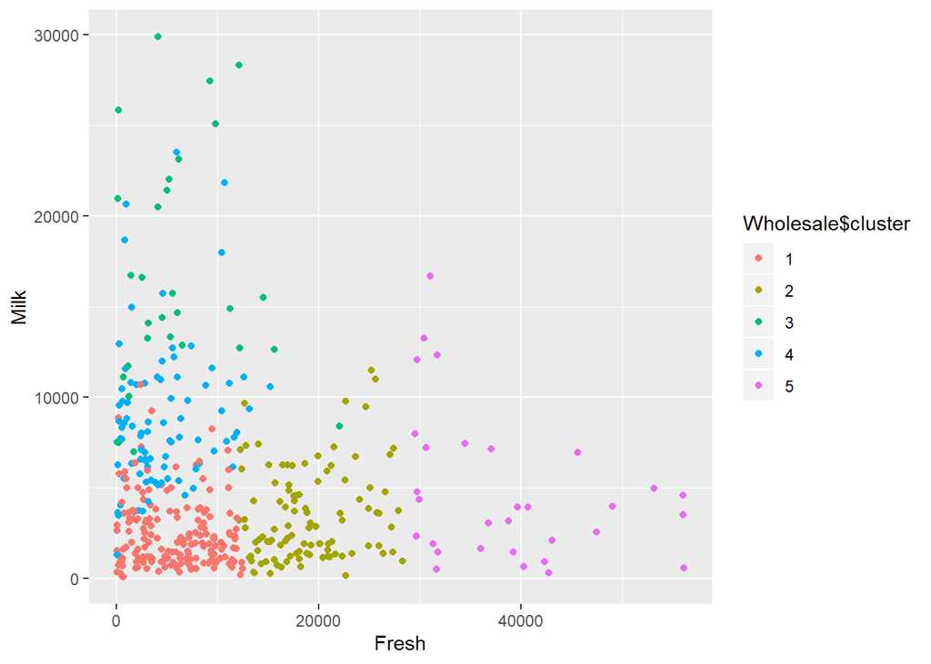

```r
sp_fresh_milk <- ggplot(Wholesale, aes(Fresh, Milk))
sp_fresh_milk <- sp_fresh_milk + geom_point(aes(color = Wholesale$cluster))
sp_fresh_milk
```

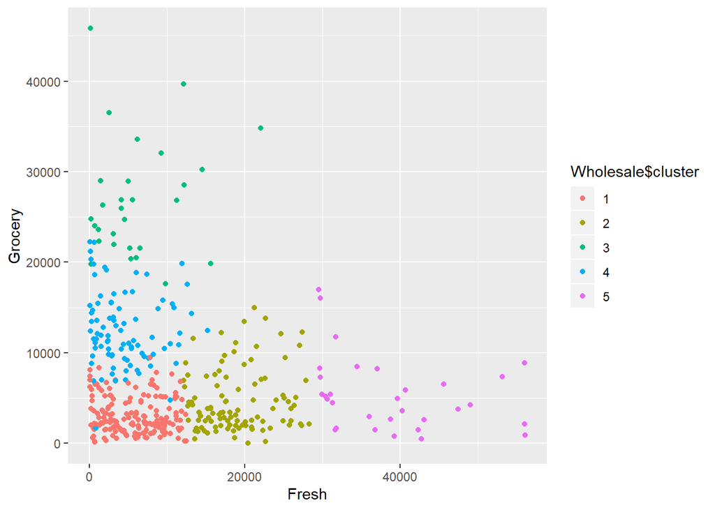

```r
sp_fresh_grocery <- ggplot(Wholesale, aes(Fresh, Grocery))
sp_fresh_grocery <- sp_fresh_grocery + geom_point(aes(color = Wholesale$cluster))
sp_fresh_grocery
```

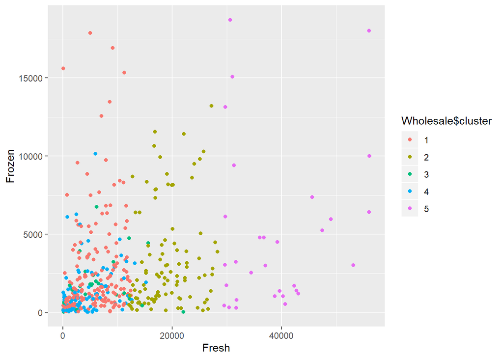

```r
sp_fresh_frozen <- ggplot(Wholesale, aes(Fresh, Frozen))
sp_fresh_frozen <- sp_fresh_frozen + geom_point(aes(color = Wholesale$cluster))
sp_fresh_frozen
```

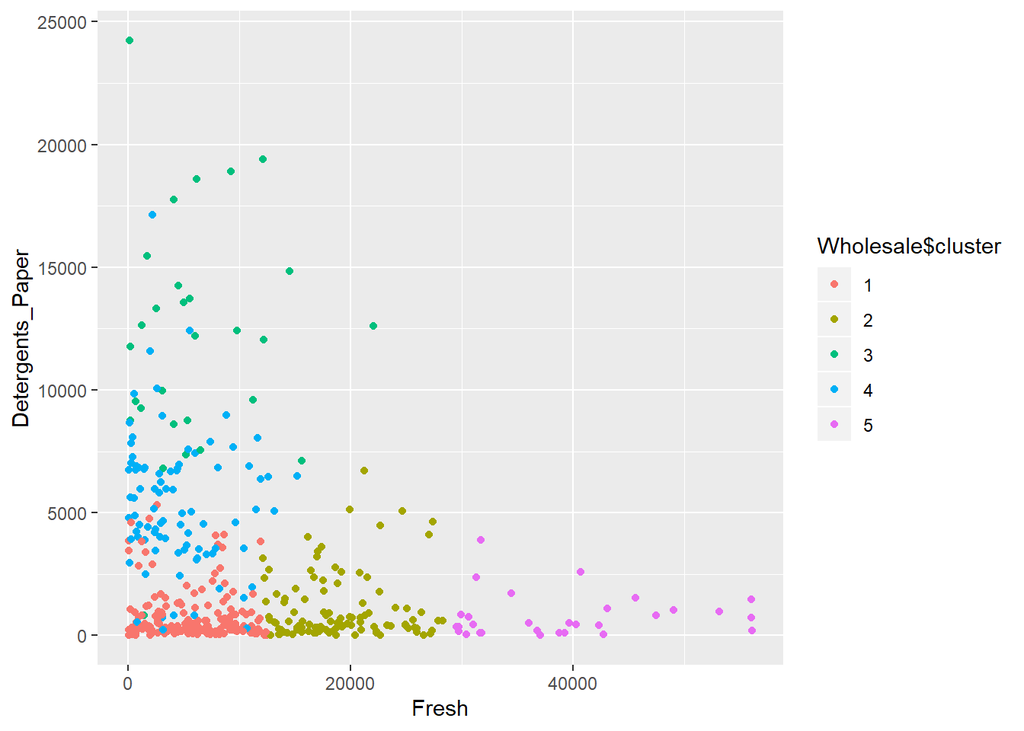

```r
sp_fresh_det <- ggplot(Wholesale, aes(Fresh, Detergents_Paper))
sp_fresh_det <- sp_fresh_det + geom_point(aes(color = Wholesale$cluster))
sp_fresh_det
```

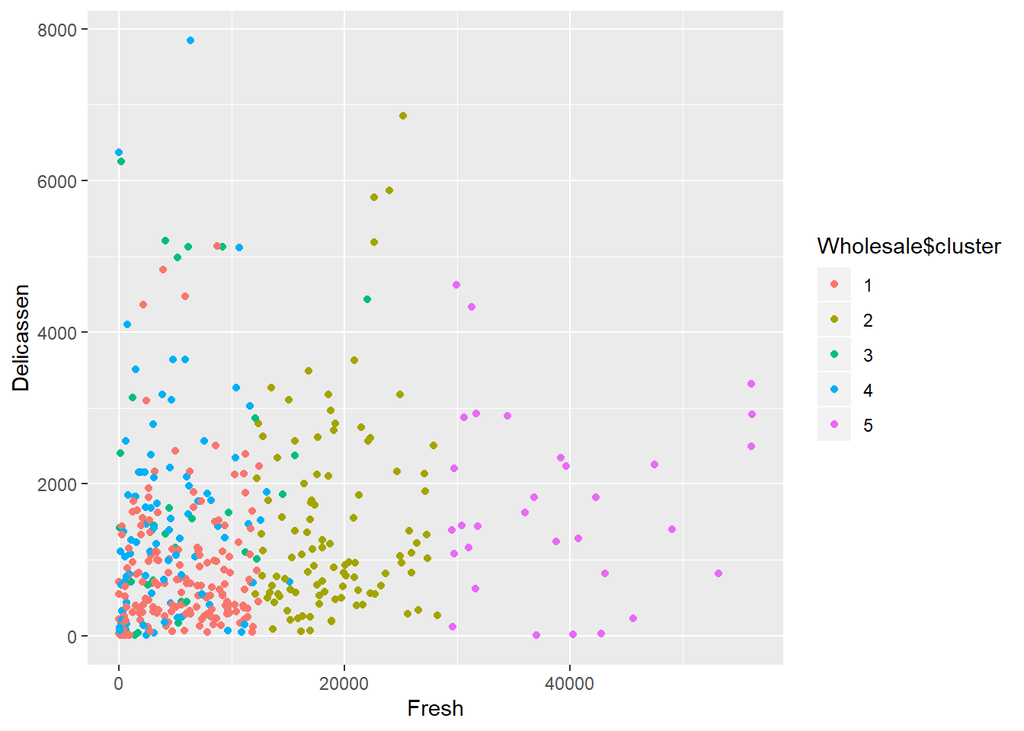

```r
sp_fresh_deli <- ggplot(Wholesale, aes(Fresh, Delicassen))
sp_fresh_deli <- sp_fresh_deli + geom_point(aes(color = Wholesale$cluster))
sp_fresh_deli
```

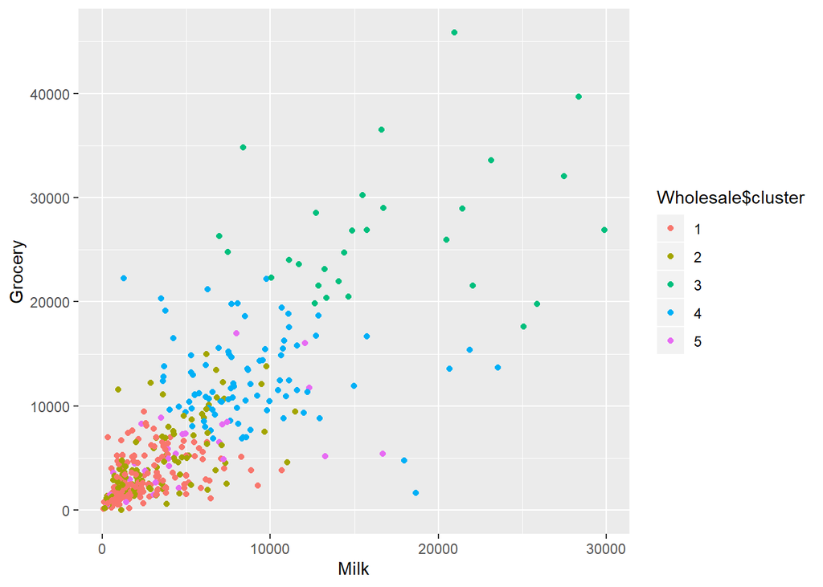

```r
sp_milk_groc <- ggplot(Wholesale, aes(Milk, Grocery))
sp_milk_groc <- sp_milk_groc + geom_point(aes(color = Wholesale$cluster))
sp_milk_groc
```

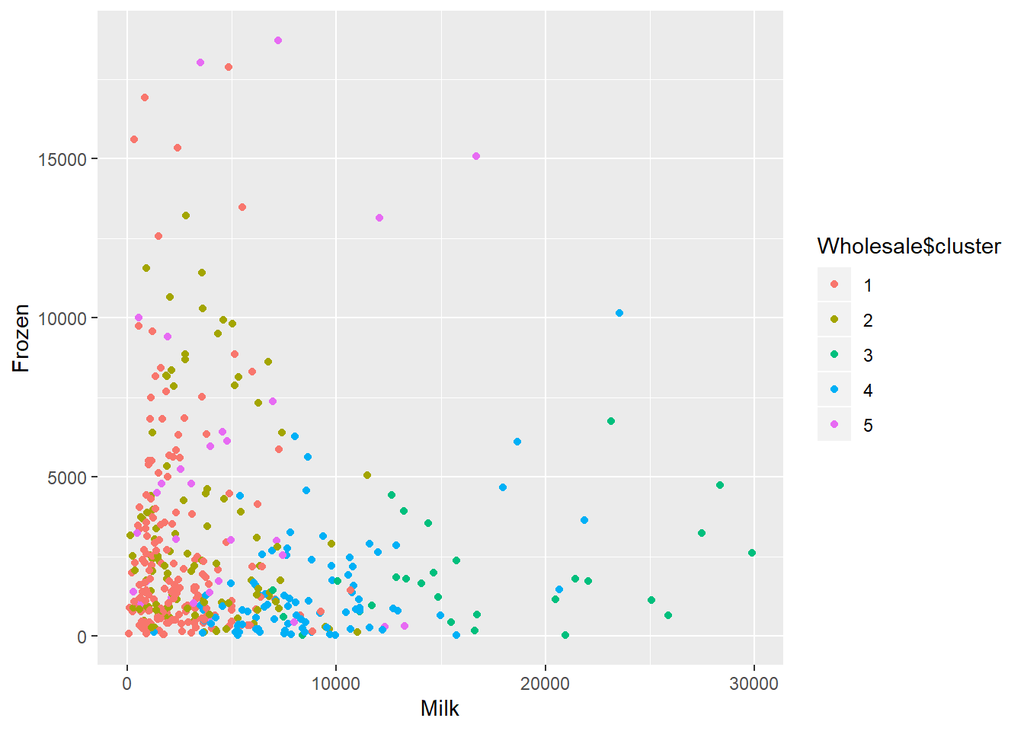

```r
sp_milk_frozen <- ggplot(Wholesale, aes(Milk, Frozen))
sp_milk_frozen <- sp_milk_frozen + geom_point(aes(color = Wholesale$cluster))
sp_milk_frozen
```

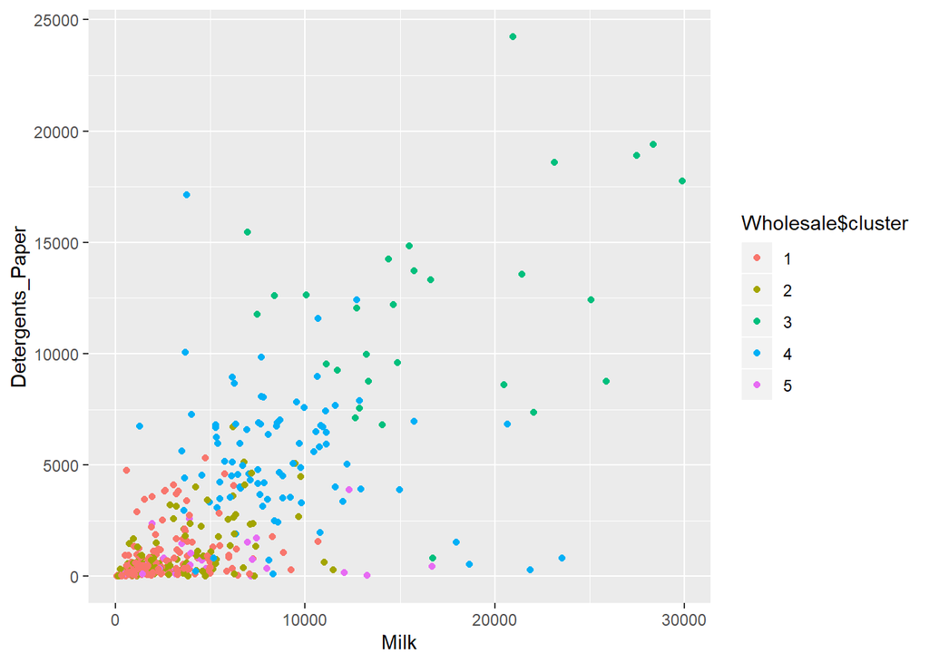

```r
sp_milk_det <- ggplot(Wholesale, aes(Milk, Detergents_Paper))
sp_milk_det <- sp_milk_det + geom_point(aes(color = Wholesale$cluster))
sp_milk_det
```

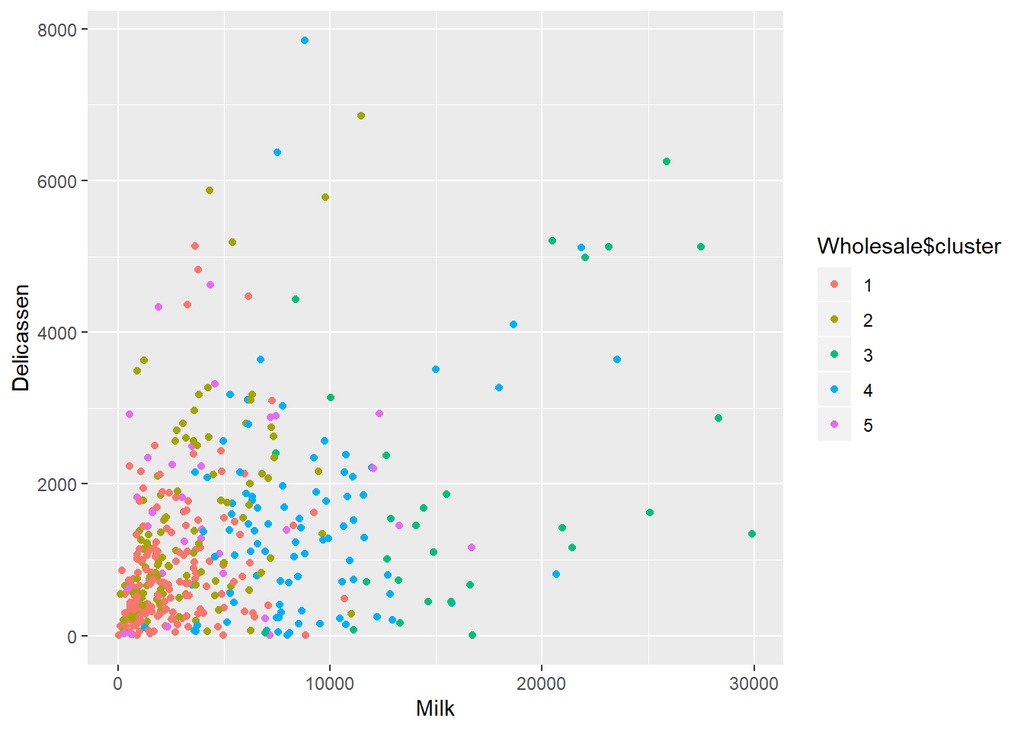

```r
sp_milk_delic <- ggplot(Wholesale, aes(Milk, Delicassen))
sp_milk_delic <- sp_milk_delic + geom_point(aes(color = Wholesale$cluster))
sp_milk_delic
```

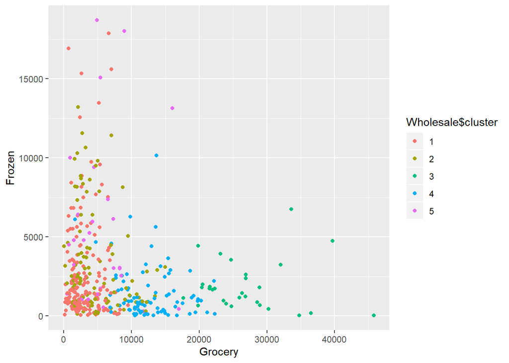

```r
sp_groc_frozen <- ggplot(Wholesale, aes(Grocery, Frozen))
sp_groc_frozen <- sp_groc_frozen + geom_point(aes(color = Wholesale$cluster))
sp_groc_frozen
```

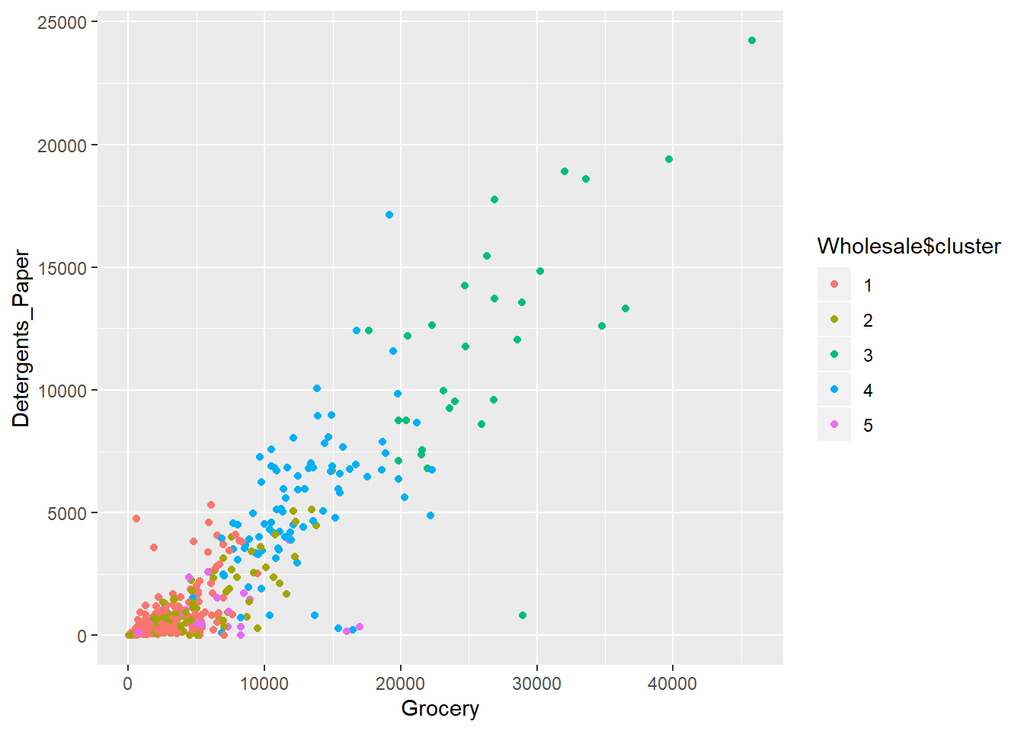

```r
sp_groc_det <- ggplot(Wholesale, aes(Grocery, Detergents_Paper))
sp_groc_det <- sp_groc_det + geom_point(aes(color = Wholesale$cluster))
sp_groc_det
```

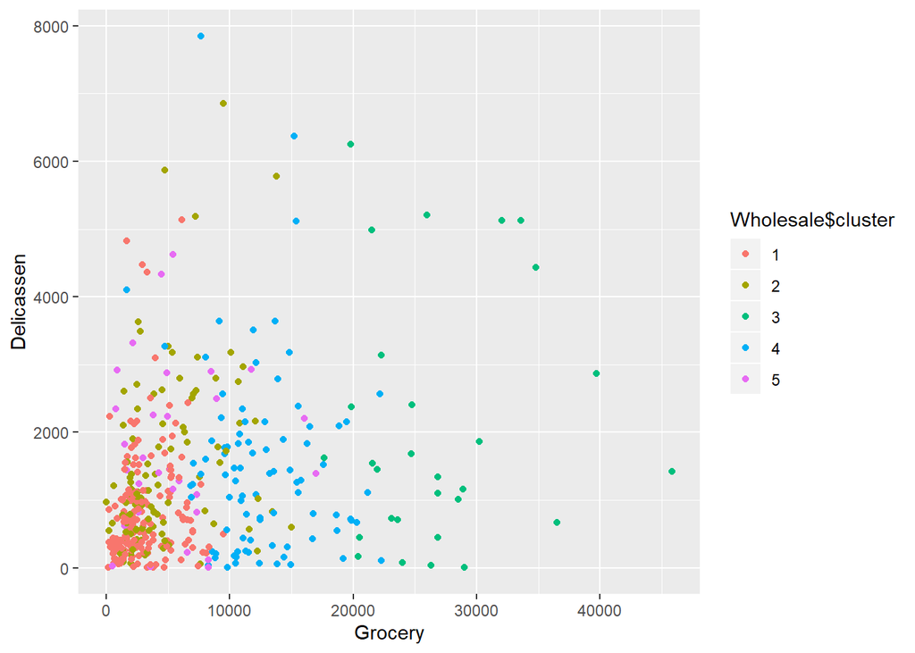

```r
sp_groc_delic <- ggplot(Wholesale, aes(Grocery, Delicassen))
sp_groc_delic <- sp_groc_delic + geom_point(aes(color = Wholesale$cluster))
sp_groc_delic
```

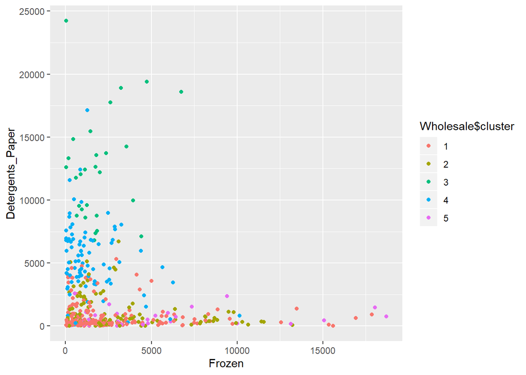

```r
sp_frozen_det <- ggplot(Wholesale, aes(Frozen, Detergents_Paper))
sp_frozen_det <- sp_frozen_det + geom_point(aes(color = Wholesale$cluster))
sp_frozen_det
```

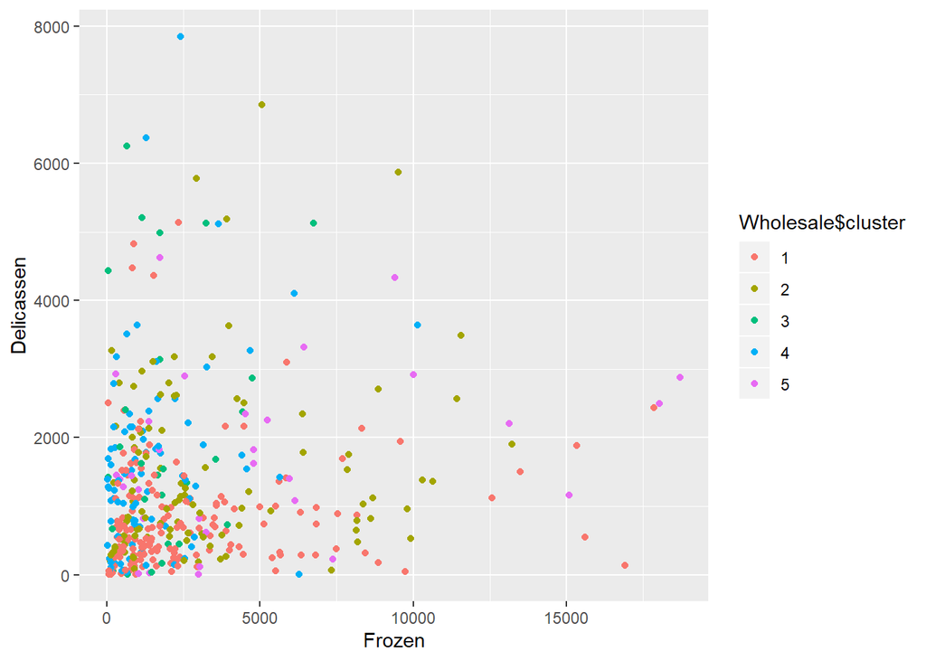

```r
sp_frozen_delic <- ggplot(Wholesale, aes(Frozen, Delicassen))
sp_frozen_delic <- sp_frozen_delic + geom_point(aes(color = Wholesale$cluster))
sp_frozen_delic
```

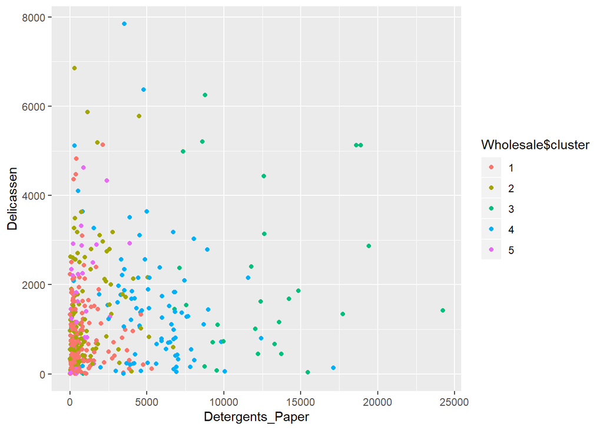

```r
sp_det_delic <- ggplot(Wholesale, aes(Detergents_Paper, Delicassen))
sp_det_delic <- sp_det_delic + geom_point(aes(color = Wholesale$cluster))
sp_det_delic
```

6. Realice al menos 3 modelos cambiando los centroides

```r
set.seed(0)
modelo_agrupacion_3c <- kmeans(Wholesale[,c(3:8)], centers = 3)
Wholesale$cluster2 <- modelo_agrupacion_3c$cluster
Wholesale$cluster2 <- factor(Wholesale$cluster2)
```

Cambiando los centroides se puede observar una agrupacion diferente de los datos, en el siguiente grafico se utilizan 3 centroides.

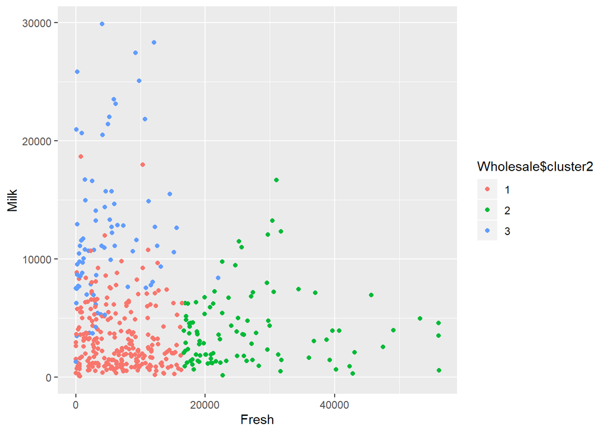

```r
sp_fresh_milk <- ggplot(Wholesale, aes(Fresh, Milk))
sp_fresh_milk <- sp_fresh_milk + geom_point(aes(color = Wholesale$cluster2))
sp_fresh_milk
```

```r
set.seed(0)
modelo_agrupacion_4c <- kmeans(Wholesale[,c(3:8)], centers = 4)
Wholesale$cluster3 <- modelo_agrupacion_4c$cluster
Wholesale$cluster3 <- factor(Wholesale$cluster3)
```

Utilizando 4 centroides se tiene

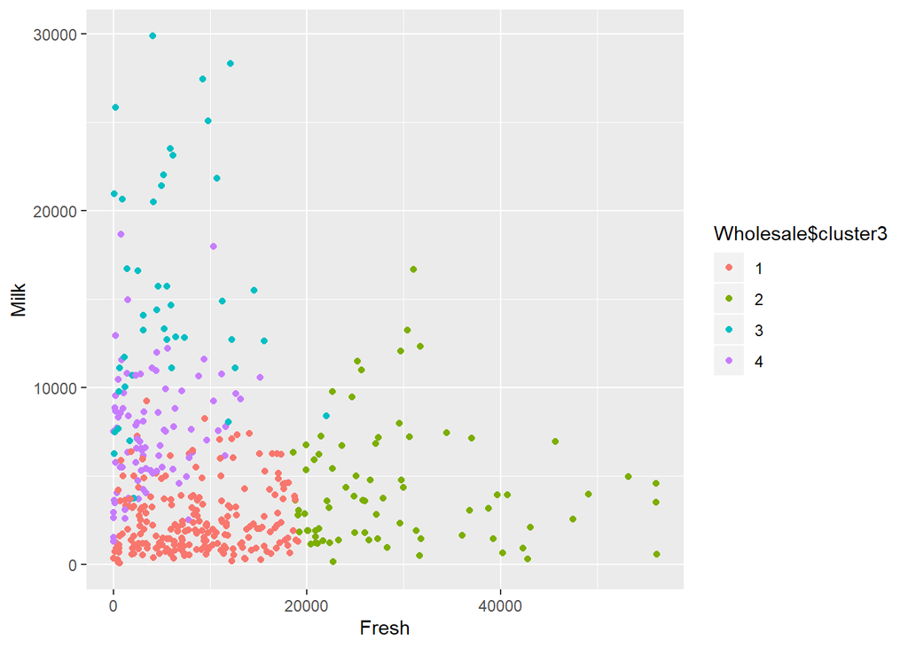

```r
sp_fresh_milk <- ggplot(Wholesale, aes(Fresh, Milk))
sp_fresh_milk <- sp_fresh_milk + geom_point(aes(color = Wholesale$cluster3))
sp_fresh_milk
```

7. Evaluacioón del modelo

A cuantinuacion las evaluaciones de cada uno de los 3 modelos desarrollados, con 5, 3 y 4 centroides respectivamente

```r
by(Wholesale[,c(1:8, 9)], Wholesale$cluster, summary)
```

```
## Wholesale$cluster: 1
##    Channel       Region        Fresh            Milk          Grocery
##  HoReCa:163   Lisbon: 33   Min.   :    3   Min.   :   55   Min.   : 137
##  Retail: 11   Oporto: 19   1st Qu.: 2559   1st Qu.: 1023   1st Qu.:1576
##               Other :122   Median : 5858   Median : 1914   Median :2442
##                            Mean   : 5708   Mean   : 2463   Mean   :3061
##                            3rd Qu.: 8695   3rd Qu.: 3328   3rd Qu.:4532
##                            Max.   :12434   Max.   :10678   Max.   :9464
##      Frozen      Detergents_Paper   Delicassen     cluster
##  Min.   :   47   Min.   :   3.0   Min.   :   3.0   1:174
##  1st Qu.:  726   1st Qu.: 183.2   1st Qu.: 304.8   2:  0
##  Median : 1470   Median : 354.0   Median : 622.5   3:  0
##  Mean   : 2699   Mean   : 794.5   Mean   : 846.1   4:  0
##  3rd Qu.: 3491   3rd Qu.: 916.5   3rd Qu.:1110.8   5:  0
##  Max.   :17866   Max.   :5316.0   Max.   :5137.0
## --------------------------------------------------------
## Wholesale$cluster: 2
##    Channel      Region       Fresh            Milk          Grocery
##  HoReCa:80   Lisbon:17   Min.   :12126   Min.   :  134   Min.   :    3
##  Retail:24   Oporto:12   1st Qu.:15599   1st Qu.: 1376   1st Qu.: 2038
##              Other :75   Median :18150   Median : 2786   Median : 3444
##                          Mean   :18938   Mean   : 3448   Mean   : 4664
##                          3rd Qu.:21748   3rd Qu.: 4888   3rd Qu.: 6654
##                          Max.   :28257   Max.   :11487   Max.   :14982
##      Frozen        Detergents_Paper   Delicassen     cluster
##  Min.   :  118.0   Min.   :   3.0   Min.   :  57.0   1:  0
##  1st Qu.:  904.2   1st Qu.: 241.0   1st Qu.: 568.5   2:104
##  Median : 2212.0   Median : 549.5   Median :1024.5   3:  0
##  Mean   : 3265.6   Mean   :1117.5   Mean   :1450.8   4:  0
##  3rd Qu.: 4276.0   3rd Qu.:1475.2   3rd Qu.:2084.2   5:  0
##  Max.   :13223.0   Max.   :6707.0   Max.   :6854.0
## --------------------------------------------------------
## Wholesale$cluster: 3
##    Channel      Region       Fresh            Milk          Grocery
##  HoReCa: 0   Lisbon: 6   Min.   :   85   Min.   : 6964   Min.   :17645
##  Retail:29   Oporto: 5   1st Qu.: 1689   1st Qu.:12697   1st Qu.:21955
##              Other :18   Median : 4967   Median :14881   Median :25957
##                          Mean   : 6004   Mean   :16814   Mean   :26819
##                          3rd Qu.: 9198   3rd Qu.:21412   3rd Qu.:28986
##                          Max.   :22039   Max.   :29892   Max.   :45828
```

[output cut: 24 more lines]

```
## Wholesale$cluster: 5
##    Channel      Region       Fresh            Milk          Grocery
##  HoReCa:28   Lisbon: 6   Min.   :29526   Min.   :  286   Min.   :  471
##  Retail: 3   Oporto: 1   1st Qu.:31144   1st Qu.: 1780   1st Qu.: 2366
##              Other :24   Median :37036   Median : 3916   Median : 4897
##                          Mean   :38772   Mean   : 4759   Mean   : 5366
##                          3rd Qu.:42937   3rd Qu.: 7055   3rd Qu.: 7331
##                          Max.   :56159   Max.   :16687   Max.   :16966
##      Frozen      Detergents_Paper   Delicassen   cluster
##  Min.   :  287   Min.   :  20.0   Min.   :   3   1: 0
##  1st Qu.: 1282   1st Qu.: 196.0   1st Qu.: 953   2: 0
##  Median : 3046   Median : 439.0   Median :1450   3: 0
##  Mean   : 5041   Mean   : 786.9   Mean   :1735   4: 0
##  3rd Qu.: 6276   3rd Qu.:1004.0   3rd Qu.:2422   5:31
##  Max.   :18711   Max.   :3881.0   Max.   :4626
```

```r
by(Wholesale[,c(1:8, 10)], Wholesale$cluster2, summary)
```

```
## Wholesale$cluster2: 1
##    Channel       Region        Fresh            Milk          Grocery
##  HoReCa:201   Lisbon: 46   Min.   :    3   Min.   :   55   Min.   :  137
##  Retail: 44   Oporto: 25   1st Qu.: 2787   1st Qu.: 1114   1st Qu.: 1765
##               Other :174   Median : 6338   Median : 2344   Median : 3045
##                            Mean   : 6709   Mean   : 3311   Mean   : 4144
##                            3rd Qu.: 9898   3rd Qu.: 4979   3rd Qu.: 6192
##                            Max.   :16448   Max.   :18664   Max.   :12822
##      Frozen      Detergents_Paper   Delicassen   cluster2
##  Min.   :   47   Min.   :   3     Min.   :   3   1:245
##  1st Qu.:  650   1st Qu.: 215     1st Qu.: 323   2:  0
##  Median : 1336   Median : 492     Median : 697   3:  0
##  Mean   : 2424   Mean   :1256     Mean   :1009
##  3rd Qu.: 2921   3rd Qu.:1682     3rd Qu.:1409
##  Max.   :17866   Max.   :7271     Max.   :7844
## --------------------------------------------------------
## Wholesale$cluster2: 2
##    Channel      Region       Fresh            Milk          Grocery
##  HoReCa:82   Lisbon:17   Min.   :16705   Min.   :  134   Min.   :    3
##  Retail:20   Oporto: 9   1st Qu.:18892   1st Qu.: 1583   1st Qu.: 2125
##              Other :76   Median :22972   Median : 3540   Median : 3840
##                          Mean   :26476   Mean   : 3984   Mean   : 5098
##                          3rd Qu.:30273   3rd Qu.: 5107   3rd Qu.: 7278
##                          Max.   :56159   Max.   :16687   Max.   :16966
##      Frozen      Detergents_Paper   Delicassen     cluster2
##  Min.   :  118   Min.   :   3.0   Min.   :   3.0   1:  0
##  1st Qu.: 1214   1st Qu.: 234.2   1st Qu.: 679.8   2:102
##  Median : 2862   Median : 508.0   Median :1254.0   3:  0
##  Mean   : 4201   Mean   :1069.4   Mean   :1629.1
##  3rd Qu.: 5813   3rd Qu.:1135.5   3rd Qu.:2248.5
##  Max.   :18711   Max.   :6707.0   Max.   :6854.0
## --------------------------------------------------------
## Wholesale$cluster2: 3
##    Channel      Region       Fresh            Milk          Grocery
##  HoReCa: 7   Lisbon:14   Min.   :   18   Min.   : 1275   Min.   : 8852
##  Retail:72   Oporto:11   1st Qu.: 1046   1st Qu.: 7949   1st Qu.:13764
##              Other :54   Median : 3366   Median :10940   Median :17645
##                          Mean   : 4833   Mean   :12296   Mean   :19380
##                          3rd Qu.: 6301   3rd Qu.:14761   3rd Qu.:22711
##                          Max.   :22039   Max.   :29892   Max.   :45828
##      Frozen        Detergents_Paper   Delicassen     cluster2
##  Min.   :   25.0   Min.   :  241    Min.   :   3.0   1: 0
##  1st Qu.:  417.5   1st Qu.: 6177    1st Qu.: 609.5   2: 0
##  Median : 1069.0   Median : 7425    Median :1282.0   3:79
##  Mean   : 1579.8   Mean   : 8647    Mean   :1652.5
##  3rd Qu.: 2113.0   3rd Qu.:10823    3rd Qu.:2125.5
##  Max.   :10155.0   Max.   :24231    Max.   :6372.0
```

```r
by(Wholesale[,c(1:8, 11)], Wholesale$cluster3, summary)
```

```
## Wholesale$cluster3: 1
##    Channel       Region        Fresh            Milk         Grocery
##  HoReCa:197   Lisbon: 40   Min.   :    3   Min.   :  55   Min.   :  137
##  Retail: 21   Oporto: 26   1st Qu.: 3918   1st Qu.:1023   1st Qu.: 1639
##               Other :152   Median : 8258   Median :1934   Median : 2506
##                            Mean   : 8587   Mean   :2461   Mean   : 3098
##                            3rd Qu.:12420   3rd Qu.:3525   3rd Qu.: 4128
##                            Max.   :19087   Max.   :9250   Max.   :12232
##      Frozen        Detergents_Paper   Delicassen     cluster3
##  Min.   :   47.0   Min.   :   3.0   Min.   :   7.0   1:218
##  1st Qu.:  826.2   1st Qu.: 175.2   1st Qu.: 342.5   2:  0
##  Median : 1571.0   Median : 342.5   Median : 686.0   3:  0
##  Mean   : 2857.5   Mean   : 715.5   Mean   : 948.5   4:  0
##  3rd Qu.: 3671.2   3rd Qu.: 847.8   3rd Qu.:1228.5
##  Max.   :17866.0   Max.   :4762.0   Max.   :5137.0
## --------------------------------------------------------
## Wholesale$cluster3: 2
##    Channel      Region       Fresh            Milk          Grocery
##  HoReCa:63   Lisbon:13   Min.   :18601   Min.   :  134   Min.   :    3
##  Retail:14   Oporto: 5   1st Qu.:21632   1st Qu.: 1780   1st Qu.: 2128
##              Other :59   Median :26400   Median : 3575   Median : 4604
##                          Mean   :29335   Mean   : 4286   Mean   : 5408
##                          3rd Qu.:31812   3rd Qu.: 6208   3rd Qu.: 7336
##                          Max.   :56159   Max.   :16687   Max.   :16966
##      Frozen      Detergents_Paper   Delicassen   cluster3
##  Min.   :  127   Min.   :   3     Min.   :   3   1: 0
##  1st Qu.: 1256   1st Qu.: 284     1st Qu.: 790   2:77
##  Median : 2915   Median : 523     Median :1384   3: 0
##  Mean   : 4316   Mean   :1106     Mean   :1775   4: 0
##  3rd Qu.: 5970   3rd Qu.:1145     3rd Qu.:2564
##  Max.   :18711   Max.   :6707     Max.   :6854
## --------------------------------------------------------
## Wholesale$cluster3: 3
##    Channel      Region       Fresh            Milk          Grocery
##  HoReCa: 2   Lisbon:10   Min.   :   85   Min.   : 3737   Min.   :13567
##  Retail:41   Oporto: 7   1st Qu.: 1548   1st Qu.:11094   1st Qu.:19633
##              Other :26   Median : 4967   Median :14069   Median :22182
##                          Mean   : 5697   Mean   :15427   Mean   :23970
##                          3rd Qu.: 8280   3rd Qu.:20807   3rd Qu.:26868
##                          Max.   :22039   Max.   :29892   Max.   :45828
```

[output cut: 8 more lines]

```
## Wholesale$cluster3: 4
##    Channel      Region       Fresh            Milk          Grocery
##  HoReCa:28   Lisbon:14   Min.   :    3   Min.   : 1275   Min.   : 1660
##  Retail:60   Oporto: 7   1st Qu.: 1004   1st Qu.: 5346   1st Qu.: 8241
##              Other :67   Median : 2909   Median : 7504   Median :10582
##                          Mean   : 3980   Mean   : 7490   Mean   :10726
##                          3rd Qu.: 5754   3rd Qu.: 9395   3rd Qu.:12860
##                          Max.   :15168   Max.   :18664   Max.   :22272
##      Frozen     Detergents_Paper   Delicassen   cluster3
##  Min.   :  25   Min.   :   93    Min.   :   3   1: 0
##  1st Qu.: 281   1st Qu.: 3314    1st Qu.: 303   2: 0
##  Median : 783   Median : 4466    Median :1226   3: 0
##  Mean   :1257   Mean   : 4537    Mean   :1350   4:88
##  3rd Qu.:1674   3rd Qu.: 6304    3rd Qu.:1833
##  Max.   :6269   Max.   :10069    Max.   :7844
```

A continuacion un grafico que muestra las ventas de cada uno de los productos en los distintos clusters

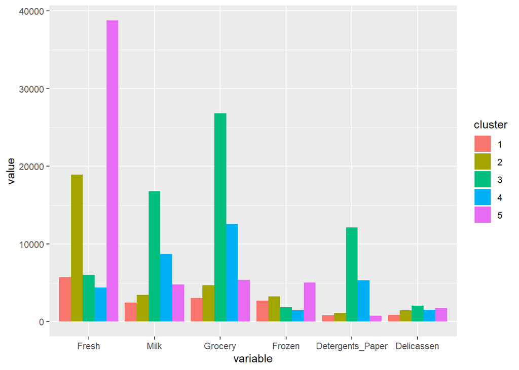

```r
promedios <- Wholesale %>% group_by(cluster) %>%
  summarise(Fresh = mean(Fresh),
            Milk = mean(Milk),
            Grocery = mean(Grocery),
            Frozen = mean(Frozen),
            Detergents_Paper = mean(Detergents_Paper),
            Delicassen = mean(Delicassen))

prom_melt <- melt(promedios, id.vars = "cluster")

g_prom <- ggplot(prom_melt,
                 aes(x = variable,
                     y = value,
                     fill = cluster)) +
  geom_bar(stat = "identity",
           position = position_dodge())

g_prom
```

8. Desarolle al menos 5 conclusiones sobre los grupos realizados

El mayor consumo se tiene en el grupo 5, variable Fresh

El menor consumo se tiene en el grupo 5, variable Detergents_Paper

En promedio el consumo de delicatessen es el menor comparado con los demas productos

El grupo 3 tiene altos consumos de Milk, Grocery y Detergent_Paper.

En promedio el consumo de fresh es mas alto que los demas productos.